# Project 1: Wrangling, Exploration, Visualization

SDS322E

## Data Wrangling, Exploration, Visualization

### Xiaoyu Zhou, xz7363

#### Introduction

This project is to further explore various data for different countries with dplyr functions and visualization. It contains two datasets named ‘country’ which includes variables of basic information for countries, such as ‘country’, ‘region’, ‘population’, ‘area’, ‘population density’, ‘coastline’, ‘net migration’, ‘infant mortality’, ‘GDP’, ‘literacy’, ‘birthrate’, ‘deathrate’, etc., and ‘internetusers’ which includes variables ‘country or area’, ‘internet users’, ‘population’, and ‘rank’. These datasets are obtained from the website: https://www.kaggle.com/datasets. These two datasets interest me because potential relationships or trends may be discovered based on different countries/regions.

```r
library(tidyverse)
country <- read_csv("countries of the world.csv")
internetusers <- read_csv("internetusers.csv")
```

#### Tidying: Reshaping

```r
head(country)
```

```
## # A tibble: 6 x 20
##   Country Region Population `Area (sq. mi.)` `Pop. Density (… `Coastline (coa…
##   <chr>   <chr>       <dbl>            <dbl> <chr>            <chr>
## 1 Afghan… ASIA …   31056997           647500 48,0             0,00
## 2 Albania EASTE…    3581655            28748 124,6            1,26
## 3 Algeria NORTH…   32930091          2381740 13,8             0,04
## 4 Americ… OCEAN…      57794              199 290,4            58,29
## 5 Andorra WESTE…      71201              468 152,1            0,00
## 6 Angola  SUB-S…   12127071          1246700 9,7              0,13
## # … with 14 more variables: `Net migration` <chr>, `Infant mortality (per 1000
## #   births)` <dbl>, `GDP ($ per capita)` <dbl>, `Literacy (%)` <dbl>, `Phones
## #   (per 1000)` <chr>, `Arable (%)` <chr>, `Crops (%)` <chr>, `Other
## #   (%)` <dbl>, Climate <dbl>, Birthrate <dbl>, Deathrate <dbl>,
## #   Agriculture <chr>, Industry <chr>, Service <chr>
```

```r
head(internetusers)
```

```
## # A tibble: 6 x 4
##   `Country or Area` `Internet Users` Population  Rank
##   <chr>                        <dbl>      <dbl> <dbl>
## 1 China                    765367947 1409517397     1
## 2 India                    461347554 1339180127     2
## 3 United States            244090854  324459463     3
## 4 Brazil                   141206801  209288278     4
## 5 Japan                    115845120  127484450     5
## 6 Russia                   109446612  143989754     6
```

```r
country %>% pivot_wider(names_from = "Region", values_from = "Population") %>%
    pivot_longer(19:29, names_to = "Region", values_to = "Population",
        values_drop_na = T)
```

```
## # A tibble: 227 x 20
##    Country `Area (sq. mi.)` `Pop. Density (… `Coastline (coa… `Net migration`
##    <chr>              <dbl> <chr>            <chr>            <chr>
##  1 Afghan…           647500 48,0             0,00             23,06
##  2 Albania            28748 124,6            1,26             -4,93
##  3 Algeria          2381740 13,8             0,04             -0,39
##  4 Americ…              199 290,4            58,29            -20,71
##  5 Andorra              468 152,1            0,00             6,6
##  6 Angola           1246700 9,7              0,13             0
##  7 Anguil…              102 132,1            59,80            10,76
##  8 Antigu…              443 156,0            34,54            -6,15
##  9 Argent…          2766890 14,4             0,18             0,61
## 10 Armenia            29800 99,9             0,00             -6,47
## # … with 217 more rows, and 15 more variables: `Infant mortality (per 1000
## #   births)` <dbl>, `GDP ($ per capita)` <dbl>, `Literacy (%)` <dbl>, `Phones
## #   (per 1000)` <chr>, `Arable (%)` <chr>, `Crops (%)` <chr>, `Other
## #   (%)` <dbl>, Climate <dbl>, Birthrate <dbl>, Deathrate <dbl>,
## #   Agriculture <chr>, Industry <chr>, Service <chr>, Region <chr>,
## #   Population <dbl>
```

Since my datasets are already tidy, I first untidy them by using pivot_wider and then retidy it with pivot_longer while dropping all the NAs originated from the untidy process.

#### Joining/Merging

```r
nrow(country)
```

```
## [1] 227
```

```r
country %>% summarize(n_distinct(Country))
```

```
## # A tibble: 1 x 1
##   `n_distinct(Country)`
##                   <int>
## 1                   227
```

```r
nrow(internetusers)
```

```
## [1] 215
```

```r
internetusers %>% summarize(n_distinct(`Country or Area`))
```

```
## # A tibble: 1 x 1
##   `n_distinct(\`Country or Area\`)`
##                               <int>
## 1                               215
```

```r
anti_join(country, internetusers, by = c(Country = "Country or Area"))
```

```
## # A tibble: 36 x 20
##    Country Region Population `Area (sq. mi.)` `Pop. Density (… `Coastline (coa…
##    <chr>   <chr>       <dbl>            <dbl> <chr>            <chr>
##  1 Americ… OCEAN…      57794              199 290,4            58,29
##  2 Antigu… LATIN…      69108              443 156,0            34,54
##  3 Bahama… LATIN…     303770            13940 21,8             25,41
##  4 Bosnia… EASTE…    4498976            51129 88,0             0,04
##  5 Britis… LATIN…      23098              153 151,0            52,29
##  6 Burma   ASIA …   47382633           678500 69,8             0,28
##  7 Cape V… SUB-S…     420979             4033 104,4            23,93
##  8 Centra… SUB-S…    4303356           622984 6,9              0,00
##  9 Congo,… SUB-S…   62660551          2345410 26,7             0,00
## 10 Congo,… SUB-S…    3702314           342000 10,8             0,05
## # … with 26 more rows, and 14 more variables: `Net migration` <chr>, `Infant
## #   mortality (per 1000 births)` <dbl>, `GDP ($ per capita)` <dbl>, `Literacy
## #   (%)` <dbl>, `Phones (per 1000)` <chr>, `Arable (%)` <chr>, `Crops
## #   (%)` <chr>, `Other (%)` <dbl>, Climate <dbl>, Birthrate <dbl>,
## #   Deathrate <dbl>, Agriculture <chr>, Industry <chr>, Service <chr>
```

```r
anti_join(internetusers, country, by = c(`Country or Area` = "Country"))
```

```
## # A tibble: 24 x 4
##    `Country or Area`                `Internet Users` Population  Rank
##    <chr>                                       <dbl>      <dbl> <dbl>
##  1 South Korea                              48484084   50982212    16
##  2 Myanmar                                  16374103   53370609    40
##  3 Ivory Coast                              10650818   24294750    48
##  4 Democratic Republic of the Congo          7011507   81339988    66
##  5 Palestinian Authority                     3208312    4920724    99
##  6 Bosnia and Herzegovina                    2437026    3507017   109
##  7 Trinidad and Tobago                       1058744    1369125   134
##  8 South Sudan                               1003542   12575714   136
##  9 Republic of the Congo                      455055    5260750   152
## 10 Montenegro                                 448260     628960   154
## # … with 14 more rows
```

```r
data <- inner_join(country, internetusers, by = c(Country = "Country or Area"))
nrow(data)
```

```
## [1] 191
```

In this section, I used inner join to combine my two dataset because this would only return countries appeared in both datasets without introducing NAs. Originally, there are 227 rows in the ‘country’ dataset with 227 distinct IDs and 215 rows in the ‘internetusers’ dataset with 215 distinct IDs. There are 36 IDs appeared in ‘country’ but not ‘internetusers’ and 24 IDs appeared in ‘internetusers’ but not ‘country’, and these IDs are dropped after the join. At the end, the joined dataset has 191 rows after dropping 36 IDs from ‘country’ and 24 IDs from ‘internetusers’.

#### Wrangling

```r
data %>% filter(Region == "EASTERN EUROPE") %>% select(Country,
    GDP = `GDP ($ per capita)`) %>% arrange(desc(GDP))
```

```
## # A tibble: 11 x 2
##    Country          GDP
##    <chr>          <dbl>
##  1 Slovenia       19000
##  2 Czech Republic 15700
##  3 Hungary        13900
##  4 Slovakia       13300
##  5 Poland         11100
##  6 Croatia        10600
##  7 Bulgaria        7600
##  8 Romania         7000
##  9 Macedonia       6700
## 10 Albania         4500
## 11 Serbia          2200
```

```r
data %>% group_by(Region) %>% summarize(avg_gdp = mean(`GDP ($ per capita)`)) %>%
    arrange(desc(avg_gdp))
```

```
## # A tibble: 11 x 2
##    Region               avg_gdp
##    <chr>                  <dbl>
##  1 NORTHERN AMERICA      30900
##  2 WESTERN EUROPE        27550
##  3 NEAR EAST             11850
##  4 BALTICS               11300
##  5 EASTERN EUROPE        10145.
##  6 OCEANIA                8544.
##  7 ASIA (EX. NEAR EAST)   8504.
##  8 LATIN AMER. & CARIB    7641.
##  9 NORTHERN AFRICA        5460
## 10 C.W. OF IND. STATES    4000
## 11 SUB-SAHARAN AFRICA     2426.
```

```r
data %>% mutate(birth_to_death_ratio = Birthrate/Deathrate)
```

```
## # A tibble: 191 x 24
##    Country Region Population.x `Area (sq. mi.)` `Pop. Density (…
##    <chr>   <chr>         <dbl>            <dbl> <chr>
##  1 Afghan… ASIA …     31056997           647500 48,0
##  2 Albania EASTE…      3581655            28748 124,6
##  3 Algeria NORTH…     32930091          2381740 13,8
##  4 Andorra WESTE…        71201              468 152,1
##  5 Angola  SUB-S…     12127071          1246700 9,7
##  6 Anguil… LATIN…        13477              102 132,1
##  7 Argent… LATIN…     39921833          2766890 14,4
##  8 Armenia C.W. …      2976372            29800 99,9
##  9 Aruba   LATIN…        71891              193 372,5
## 10 Austra… OCEAN…     20264082          7686850 2,6
## # … with 181 more rows, and 19 more variables: `Coastline (coast/area
## #   ratio)` <chr>, `Net migration` <chr>, `Infant mortality (per 1000
## #   births)` <dbl>, `GDP ($ per capita)` <dbl>, `Literacy (%)` <dbl>, `Phones
## #   (per 1000)` <chr>, `Arable (%)` <chr>, `Crops (%)` <chr>, `Other
## #   (%)` <dbl>, Climate <dbl>, Birthrate <dbl>, Deathrate <dbl>,
## #   Agriculture <chr>, Industry <chr>, Service <chr>, `Internet Users` <dbl>,
## #   Population.y <dbl>, Rank <dbl>, birth_to_death_ratio <dbl>
```

```r
data %>% mutate(Region = str_replace_all(Region, "ASIA.+", "ASIA"))
```

```
## # A tibble: 191 x 23
##    Country Region Population.x `Area (sq. mi.)` `Pop. Density (…
##    <chr>   <chr>         <dbl>            <dbl> <chr>
##  1 Afghan… ASIA       31056997           647500 48,0
##  2 Albania EASTE…      3581655            28748 124,6
##  3 Algeria NORTH…     32930091          2381740 13,8
##  4 Andorra WESTE…        71201              468 152,1
##  5 Angola  SUB-S…     12127071          1246700 9,7
##  6 Anguil… LATIN…        13477              102 132,1
##  7 Argent… LATIN…     39921833          2766890 14,4
##  8 Armenia C.W. …      2976372            29800 99,9
##  9 Aruba   LATIN…        71891              193 372,5
## 10 Austra… OCEAN…     20264082          7686850 2,6
## # … with 181 more rows, and 18 more variables: `Coastline (coast/area
## #   ratio)` <chr>, `Net migration` <chr>, `Infant mortality (per 1000
## #   births)` <dbl>, `GDP ($ per capita)` <dbl>, `Literacy (%)` <dbl>, `Phones
## #   (per 1000)` <chr>, `Arable (%)` <chr>, `Crops (%)` <chr>, `Other
## #   (%)` <dbl>, Climate <dbl>, Birthrate <dbl>, Deathrate <dbl>,
## #   Agriculture <chr>, Industry <chr>, Service <chr>, `Internet Users` <dbl>,
## #   Population.y <dbl>, Rank <dbl>
```

```r
data %>% summarize_if(is.numeric, list(mean = mean, sd = sd,
    var = var), na.rm = T)
```

```
## # A tibble: 1 x 36
##   Population.x_me… `Area (sq. mi.)… `Infant mortali… `GDP ($ per cap…
##              <dbl>            <dbl>            <dbl>            <dbl>
## 1        32984467.          684762.            3257.            10100
## # … with 32 more variables: `Literacy (%)_mean` <dbl>, `Other (%)_mean` <dbl>,
## #   Climate_mean <dbl>, Birthrate_mean <dbl>, Deathrate_mean <dbl>, `Internet
## #   Users_mean` <dbl>, Population.y_mean <dbl>, Rank_mean <dbl>,
## #   Population.x_sd <dbl>, `Area (sq. mi.)_sd` <dbl>, `Infant mortality (per
## #   1000 births)_sd` <dbl>, `GDP ($ per capita)_sd` <dbl>, `Literacy
## #   (%)_sd` <dbl>, `Other (%)_sd` <dbl>, Climate_sd <dbl>, Birthrate_sd <dbl>,
## #   Deathrate_sd <dbl>, `Internet Users_sd` <dbl>, Population.y_sd <dbl>,
## #   Rank_sd <dbl>, Population.x_var <dbl>, `Area (sq. mi.)_var` <dbl>, `Infant
## #   mortality (per 1000 births)_var` <dbl>, `GDP ($ per capita)_var` <dbl>,
## #   `Literacy (%)_var` <dbl>, `Other (%)_var` <dbl>, Climate_var <dbl>,
## #   Birthrate_var <dbl>, Deathrate_var <dbl>, `Internet Users_var` <dbl>,
## #   Population.y_var <dbl>, Rank_var <dbl>
```

```r
stat <- data %>% group_by(Region) %>% summarize_if(is.numeric,
    list(min = min, max = max), na.rm = T) %>% pivot_longer(-1) %>%
    separate(name, into = c("name", "stat"), sep = "_") %>% pivot_wider()
library(gt)
stat %>% gt
```

| Region | stat | Population.x | Area (sq. mi.) | Infant mortality (per 1000 births) | GDP ($ per capita) | Literacy (%) | Other (%) | Climate | Birthrate | Deathrate | Internet Users | Population.y | Rank |
| --- | --- | --- | --- | --- | --- | --- | --- | --- | --- | --- | --- | --- | --- |
| ASIA (EX. NEAR EAST) | min | 359008 | 28 | 64 | 700 | 360 | 70 | 1 | 17 | 127 | 275717 | 428697 | 1 |
| ASIA (EX. NEAR EAST) | max | 1313973713 | 9596960 | 16307 | 28800 | 990 | 9923 | 25 | 3549 | 2034 | 765367947 | 1409517397 | 169 |
| BALTICS | min | 1324333 | 45226 | 689 | 10200 | 996 | 5387 | 3 | 875 | 1098 | 1153786 | 1309632 | 115 |
| BALTICS | max | 3585906 | 65200 | 955 | 12300 | 998 | 8351 | 3 | 1004 | 1366 | 2243448 | 2890297 | 133 |
| C.W. OF IND. STATES | min | 2976372 | 29800 | 711 | 1000 | 970 | 847 | 1 | 16 | 86 | 1223591 | 2930450 | 6 |
| C.W. OF IND. STATES | max | 142893540 | 17075200 | 11076 | 8900 | 997 | 9614 | 25 | 3265 | 1465 | 109446612 | 143989754 | 132 |
| EASTERN EUROPE | min | 2010347 | 20273 | 393 | 2200 | 865 | 4785 | 3 | 107 | 522 | 1589659 | 2079976 | 28 |
| EASTERN EUROPE | max | 38536869 | 312685 | 2643 | 19000 | 999 | 8991 | 3 | 1511 | 1427 | 29005924 | 38170712 | 124 |
| LATIN AMER. & CARIB | min | 9439 | 102 | 88 | 1600 | 529 | 80 | 2 | 233 | 52 | 2833 | 5177 | 4 |
| LATIN AMER. & CARIB | max | 188078227 | 8511965 | 7345 | 35000 | 988 | 9957 | 15 | 3644 | 1217 | 141206801 | 209288278 | 212 |
| NEAR EAST | min | 698585 | 665 | 615 | 800 | 404 | 694 | 1 | 178 | 44 | 952369 | 1179551 | 14 |
| NEAR EAST | max | 70413958 | 1960582 | 5025 | 23200 | 976 | 9974 | 3 | 4289 | 768 | 52225879 | 80745020 | 140 |
| NORTHERN AFRICA | min | 5900754 | 163610 | 31 | 4000 | 517 | 684 | 1 | 1552 | 348 | 1387116 | 6374616 | 18 |
| NORTHERN AFRICA | max | 78887007 | 2381740 | 4162 | 6900 | 826 | 9878 | 3 | 2649 | 558 | 43850141 | 97553151 | 130 |
| NORTHERN AMERICA | min | 56361 | 53 | 65 | 20000 | 970 | 80 | 1 | 114 | 78 | 39242 | 56480 | 3 |
| NORTHERN AMERICA | max | 298444215 | 9984670 | 1582 | 37800 | 980 | 9502 | 3 | 1593 | 826 | 244090854 | 324459463 | 197 |
| OCEANIA | min | 11810 | 21 | 469 | 800 | 500 | 70 | 1 | 1214 | 67 | 1383 | 11192 | 34 |
| OCEANIA | max | 20264082 | 7686850 | 5516 | 29000 | 1000 | 9929 | 3 | 3305 | 826 | 21159515 | 24450561 | 213 |
| SUB-SAHARAN AFRICA | min | 7502 | 413 | 19 | 500 | 176 | 89 | 1 | 41 | 22 | 2906 | 4534 | 12 |
| SUB-SAHARAN AFRICA | max | 131859731 | 2505810 | 19119 | 11400 | 970 | 9996 | 25 | 5073 | 2974 | 31858027 | 190015955 | 210 |
| WESTERN EUROPE | min | 27928 | 2 | 37 | 17500 | 928 | 75 | 3 | 93 | 81 | 20100 | 33400 | 9 |
| WESTERN EUROPE | max | 82422299 | 547030 | 624 | 55100 | 1000 | 9993 | 4 | 1445 | 1291 | 69304405 | 82114224 | 204 |

```r
data %>% summarize_all(function(x) sum(is.na(x)))
```

```
## # A tibble: 1 x 23
##   Country Region Population.x `Area (sq. mi.)` `Pop. Density (… `Coastline (coa…
##     <int>  <int>        <int>            <int>            <int>            <int>
## 1       0      0            0                0                0                0
## # … with 17 more variables: `Net migration` <int>, `Infant mortality (per 1000
## #   births)` <int>, `GDP ($ per capita)` <int>, `Literacy (%)` <int>, `Phones
## #   (per 1000)` <int>, `Arable (%)` <int>, `Crops (%)` <int>, `Other
## #   (%)` <int>, Climate <int>, Birthrate <int>, Deathrate <int>,
## #   Agriculture <int>, Industry <int>, Service <int>, `Internet Users` <int>,
## #   Population.y <int>, Rank <int>
```

```r
data %>% group_by(Region) %>% summarize(n())
```

```
## # A tibble: 11 x 2
##    Region               `n()`
##    <chr>                <int>
##  1 ASIA (EX. NEAR EAST)    24
##  2 BALTICS                  3
##  3 C.W. OF IND. STATES     12
##  4 EASTERN EUROPE          11
##  5 LATIN AMER. & CARIB     34
##  6 NEAR EAST               14
##  7 NORTHERN AFRICA          5
##  8 NORTHERN AMERICA         4
##  9 OCEANIA                 16
## 10 SUB-SAHARAN AFRICA      42
## 11 WESTERN EUROPE          26
```

After computing summary statistics, I found it interesting that the smallest country in Western Europe is only 2 square mile, and the maximum GDPs of countries in Northern Africa and Commonwealth of Independent States are lower than total average GDP.

#### Visualizing

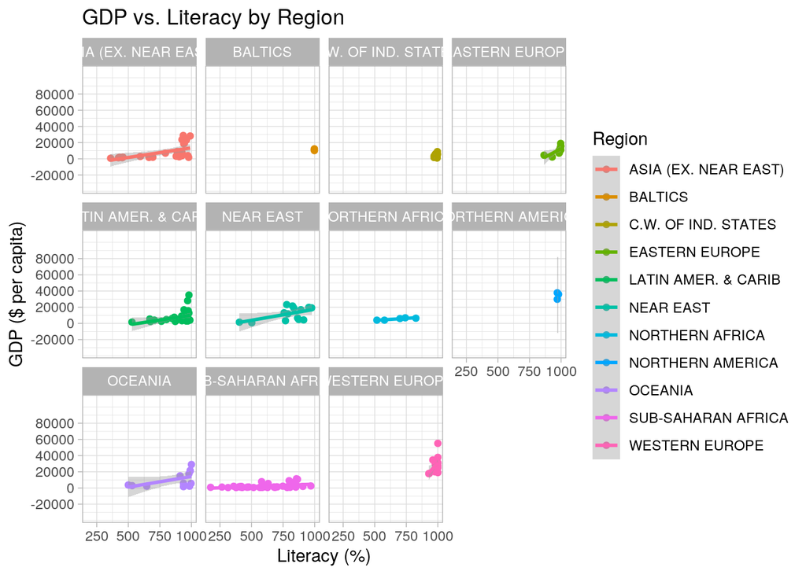

```r
data %>% ggplot(aes(`Literacy (%)`, `GDP ($ per capita)`, color = Region)) +
    geom_point() + geom_smooth(method = "lm") + facet_wrap(~Region) +
    ggtitle("GDP vs. Literacy by Region") + theme_light() + scale_y_continuous(breaks = seq(-20000,
    80000, 20000))
```

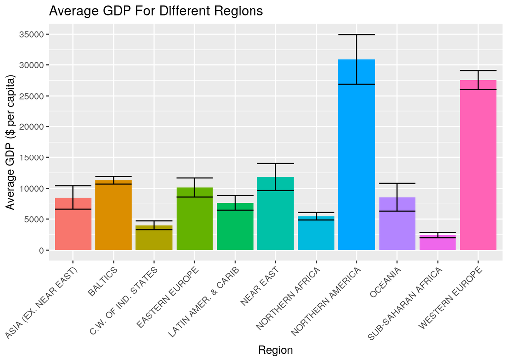

```r
data %>% ggplot(aes(Region)) + geom_bar(aes(y = `GDP ($ per capita)`,
    fill = Region), stat = "summary", fun = mean) + geom_errorbar(aes(y = `GDP ($ per capita)`),
    stat = "summary", fun.data = mean_se) + theme(axis.text.x = element_text(angle = 45,
    hjust = 1), legend.position = "none") + scale_y_continuous(n.breaks = 8) +
    ggtitle("Average GDP For Different Regions") + ylab("Average GDP ($ per capita)")
```

This bar graph depicts average GDP at different regions. And from the graph, we can see that Northern America and Western Europe have the highest average GDP, while C.W. of Ind. States and Sub-saharan Africa have the lowest average GDP.

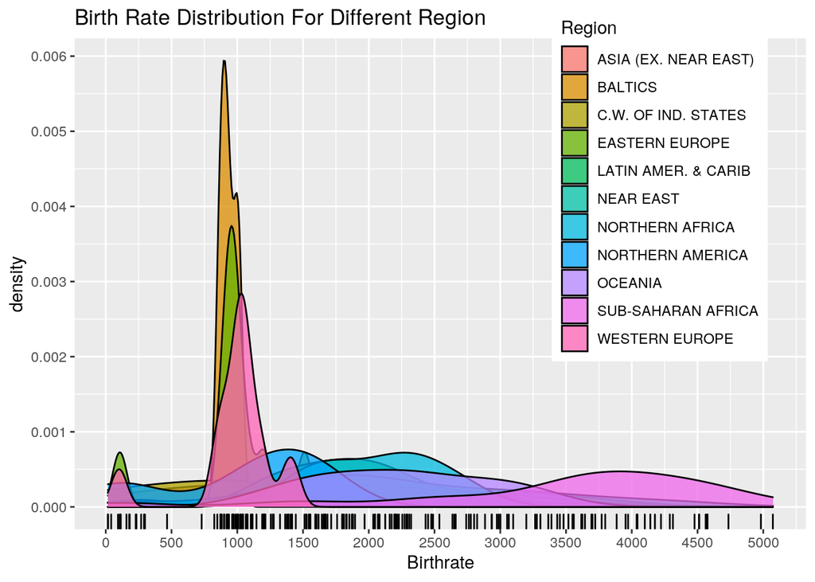

```r
data %>% ggplot(aes(x = Birthrate, fill = Region)) + geom_density(alpha = 0.75) +
    geom_rug() + theme(legend.position = c(0.8, 0.7)) + ggtitle("Birth Rate Distribution For Different Region") +
    scale_y_continuous(n.breaks = 7) + scale_x_continuous(n.breaks = 11)
```